# Lesson 2 - Problema de Regressão Linear

Filipe Penati

# Carregando os dados

```r
library(knitr)
load("lesson2_housingSmall.RData")
```

# Vizualizando os dados

Os dados apresentam informações sobre a área contruída, quantidade de quartos, vagas de garagem e o respectivo preço de 14 imóveis.

```r
head(hr)
```

```
## # A tibble: 6 x 5
##     Obs  area garagem quartos preco
##   <dbl> <dbl>   <dbl>   <dbl> <dbl>
## 1     1  1          0       2   130
## 2     2  1.1        0       2   146
## 3     3  1.15       0       2   120
## 4     4  1.33       1       3   225
## 5     5  1.4        0       3   200
## 6     6  1.5        1       3   180
```

```r
str(hr)
```

```
## Classes 'tbl_df', 'tbl' and 'data.frame':    14 obs. of  5 variables:
##  $ Obs    : num  1 2 3 4 5 6 7 8 9 10 ...
##  $ area   : num  1 1.1 1.15 1.33 1.4 1.5 1.55 1.7 1.8 1.95 ...
##  $ garagem: num  0 0 0 1 0 1 2 1 1 0 ...
##  $ quartos: num  2 2 2 3 3 3 3 2 4 1 ...
##  $ preco  : num  130 146 120 225 200 180 200 210 250 160 ...
```

```r
summary(hr)
```

```
##       Obs             area          garagem          quartos
##  Min.   : 1.00   Min.   :1.000   Min.   :0.0000   Min.   :1.000
##  1st Qu.: 4.25   1st Qu.:1.347   1st Qu.:0.0000   1st Qu.:2.000
##  Median : 7.50   Median :1.625   Median :1.0000   Median :3.000
##  Mean   : 7.50   Mean   :1.663   Mean   :0.9286   Mean   :2.643
##  3rd Qu.:10.75   3rd Qu.:2.025   3rd Qu.:1.7500   3rd Qu.:3.000
##  Max.   :14.00   Max.   :2.350   Max.   :2.0000   Max.   :4.000
##      preco
##  Min.   :120.0
##  1st Qu.:160.0
##  Median :200.0
##  Mean   :192.5
##  3rd Qu.:221.2
##  Max.   :274.0
```

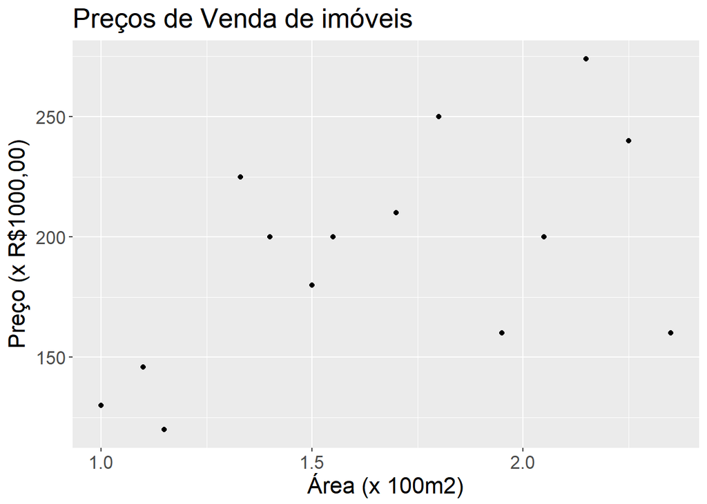

## Modelos de Previssão

A fim de obter um modelo para a previsão de preço dos apartamentos, foram analizados 3 modelos de regressão baseando-se nos atributos dos apartamentos (área, quartos e garagem).

#### Regressão Linear

lm_linear <- lm(data=hr, preco~area+garagem+quartos)

#### Regressão Quadrática

lm_quadra <- lm(data=hr, preco~poly(area+garagem+quartos,2,raw=TRUE))

#### Regressão Polinomial

lm_poli <- lm(data=hr, preco~poly(area+garagem+quartos,17,raw=TRUE))

## Vizualizando resultados

No gráfico abaixo, é possível vizualizar a distribuição dos erros residuais de cada modelo, bem como o erro médio quadrático, representado pelo triângulo. Com isso vemos que o modelo que mais de aproxima dos dados disponíveis é a Regessão polinomial.

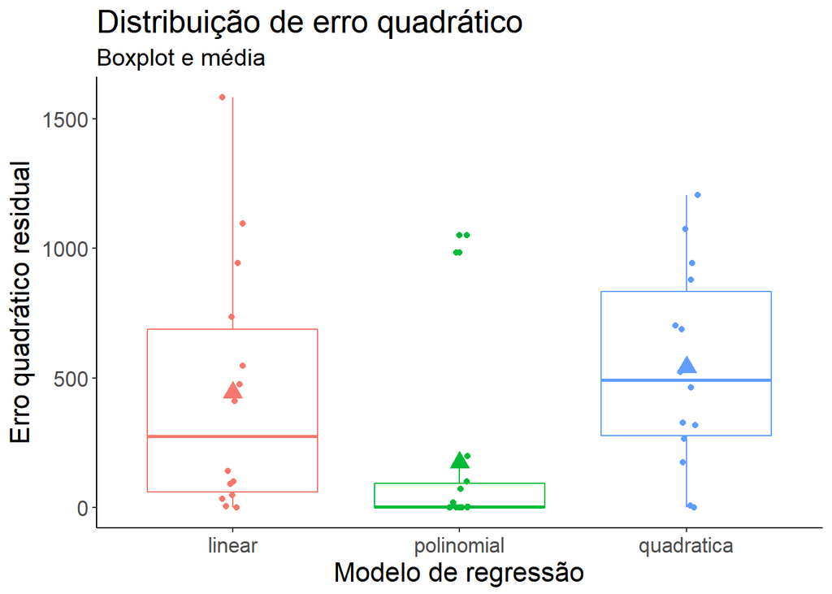

```r
residuais.plot
```

Entretando, verificando o erro padrão residual e o R-quadrado ajustado de cada modelo, é possível ver que o modelo de regressão Linear possiu melhores índices (menor erro e maior R), apresentando-se como o melhor modelo a ser adotado para a previsão de preço de apartamento. Abaixo é possivel ver o erro padrão residual e o R-quadrado ajustado de cada modelo:

```r
kable(erros_e_r2)
```

| modelo | Residual.standard_error | Adjusted.R.squared |
| --- | --- | --- |
| linear | 24.91795 | 0.7046505 |
| quadrático | 26.23234 | 0.6726701 |
| polinomial | 34.86541 | 0.4217692 |